# R Project Report

Michal Rajczak

11/24/2020

# Wstęp

# Charakterystyka danych

Zbiór danych składał się ze zbioru badań 375 pacjentów przy czym każde badanie składało się z wybranych testów oraz daty wykonania badania. Dodatkowo każdy z pacjentów był opisany przez wiek, płeć, date przyjęcia do szpitala, datę opuszczenia szpitala oraz parametr określający czy pacjent przeżył. Podstawowe statystyki związanze z konkretnymi badaniami zostały przedstawione ponieżej.

## Podstawowe statystyki testów

| Hypersensitive_cardiac_troponinI | Min. : 1.9 | 1st Qu.: 4.4 | Median : 20.6 | Mean : 1223.2 | 3rd Qu.: 223.8 | Max. :50000.0 | NA’s :5613 |
| --- | --- | --- | --- | --- | --- | --- | --- |
| hemoglobin | Min. : 6.4 | 1st Qu.:113.0 | Median :125.0 | Mean :123.1 | 3rd Qu.:137.0 | Max. :178.0 | NA’s :5145 |
| Serum_chloride | Min. : 71.50 | 1st Qu.: 99.05 | Median :102.10 | Mean :103.14 | 3rd Qu.:105.65 | Max. :140.40 | NA’s :5145 |
| Prothrombin_time | Min. : 11.50 | 1st Qu.: 13.60 | Median : 14.80 | Mean : 16.68 | 3rd Qu.: 16.70 | Max. :120.00 | NA’s :5458 |
| procalcitonin | Min. : 0.020 | 1st Qu.: 0.040 | Median : 0.100 | Mean : 1.107 | 3rd Qu.: 0.405 | Max. :57.170 | NA’s :5661 |
| eosinophils… | Min. :0.000 | 1st Qu.:0.000 | Median :0.100 | Mean :0.629 | 3rd Qu.:0.800 | Max. :8.600 | NA’s :5163 |
| Interleukin_2_receptor | Min. : 61.0 | 1st Qu.: 459.5 | Median : 676.5 | Mean : 907.2 | 3rd Qu.:1155.5 | Max. :7500.0 | NA’s :5852 |
| Alkaline_phosphatase | Min. : 17.00 | 1st Qu.: 54.00 | Median : 69.50 | Mean : 82.47 | 3rd Qu.: 95.00 | Max. :620.00 | NA’s :5190 |
| albumin | Min. :13.60 | 1st Qu.:27.40 | Median :32.20 | Mean :32.01 | 3rd Qu.:36.60 | Max. :48.60 | NA’s :5186 |
| basophil… | Min. :0.00 | 1st Qu.:0.10 | Median :0.20 | Mean :0.21 | 3rd Qu.:0.30 | Max. :1.70 | NA’s :5163 |
| Interleukin_10 | Min. : 5.00 | 1st Qu.: 5.00 | Median : 5.90 | Mean : 16.07 | 3rd Qu.: 12.35 | Max. :1000.00 | NA’s :5853 |
| Total_bilirubin | Min. : 2.50 | 1st Qu.: 7.40 | Median : 10.70 | Mean : 16.70 | 3rd Qu.: 16.77 | Max. :505.70 | NA’s :5190 |
| Platelet_count | Min. : -1.0 | 1st Qu.:109.0 | Median :178.0 | Mean :184.3 | 3rd Qu.:248.0 | Max. :558.0 | NA’s :5163 |
| monocytes… | Min. : 0.300 | 1st Qu.: 2.800 | Median : 5.700 | Mean : 6.155 | 3rd Qu.: 8.600 | Max. :53.000 | NA’s :5162 |
| antithrombin | Min. : 20.00 | 1st Qu.: 74.00 | Median : 86.00 | Mean : 85.32 | 3rd Qu.: 97.00 | Max. :136.00 | NA’s :5790 |
| Interleukin_8 | Min. : 5.000 | 1st Qu.: 8.675 | Median : 16.000 | Mean : 83.088 | 3rd Qu.: 35.200 | Max. :6795.000 | NA’s :5852 |
| indirect_bilirubin | Min. : 0.100 | 1st Qu.: 3.800 | Median : 5.400 | Mean : 6.889 | 3rd Qu.: 8.000 | Max. :145.100 | NA’s :5214 |
| Red_blood_cell_distribution_width | Min. :10.60 | 1st Qu.:12.00 | Median :12.60 | Mean :13.07 | 3rd Qu.:13.70 | Max. :27.10 | NA’s :5197 |
| neutrophils… | Min. : 1.7 | 1st Qu.:65.1 | Median :82.4 | Mean :77.6 | 3rd Qu.:92.3 | Max. :98.9 | NA’s :5163 |
| total_protein | Min. :31.80 | 1st Qu.:61.00 | Median :65.90 | Mean :65.30 | 3rd Qu.:70.45 | Max. :88.70 | NA’s :5189 |
| Quantification_of_Treponema_pallidum_antibodies | Min. : 0.020 | 1st Qu.: 0.040 | Median : 0.050 | Mean : 0.132 | 3rd Qu.: 0.070 | Max. :11.950 | NA’s :5841 |
| Prothrombin_activity | Min. : 6.00 | 1st Qu.: 65.00 | Median : 81.00 | Mean : 78.55 | 3rd Qu.: 95.00 | Max. :142.00 | NA’s :5461 |
| HBsAg | Min. : 0.000 | 1st Qu.: 0.000 | Median : 0.010 | Mean : 8.306 | 3rd Qu.: 0.010 | Max. :250.000 | NA’s :5841 |
| mean_corpuscular_volume | Min. : 61.60 | 1st Qu.: 86.90 | Median : 90.10 | Mean : 90.39 | 3rd Qu.: 93.90 | Max. :118.90 | NA’s :5163 |
| hematocrit | Min. :14.50 | 1st Qu.:33.50 | Median :36.60 | Mean :36.55 | 3rd Qu.:39.90 | Max. :52.30 | NA’s :5163 |
| White_blood_cell_count | Min. : 0.13 | 1st Qu.: 4.94 | Median : 7.72 | Mean : 15.60 | 3rd Qu.: 12.72 | Max. :1726.60 | NA’s :4993 |
| Tumor_necrosis_factorα | Min. : 4.00 | 1st Qu.: 6.70 | Median : 8.60 | Mean : 11.58 | 3rd Qu.: 11.50 | Max. :168.00 | NA’s :5852 |
| mean_corpuscular_hemoglobin_concentration | Min. :286.0 | 1st Qu.:333.0 | Median :343.0 | Mean :342.8 | 3rd Qu.:350.0 | Max. :514.0 | NA’s :5163 |
| fibrinogen | Min. : 0.500 | 1st Qu.: 3.050 | Median : 4.120 | Mean : 4.294 | 3rd Qu.: 5.480 | Max. :10.780 | NA’s :5554 |
| Interleukin_1β | Min. : 5.00 | 1st Qu.: 5.00 | Median : 5.00 | Mean : 6.51 | 3rd Qu.: 5.00 | Max. :88.50 | NA’s :5852 |
| Urea | Min. : 0.800 | 1st Qu.: 4.000 | Median : 5.985 | Mean : 9.589 | 3rd Qu.:11.400 | Max. :68.400 | NA’s :5184 |
| lymphocyte_count | Min. : 0.000 | 1st Qu.: 0.460 | Median : 0.800 | Mean : 1.017 | 3rd Qu.: 1.310 | Max. :52.420 | NA’s :5163 |
| PH_value | Min. :5.000 | 1st Qu.:6.000 | Median :6.500 | Mean :6.484 | 3rd Qu.:7.294 | Max. :7.565 | NA’s :5736 |
| Red_blood_cell_count | Min. : 0.100 | 1st Qu.: 3.680 | Median : 4.140 | Mean : 9.288 | 3rd Qu.: 4.650 | Max. :749.500 | NA’s :4993 |
| Eosinophil_count | Min. :0.000 | 1st Qu.:0.000 | Median :0.010 | Mean :0.039 | 3rd Qu.:0.060 | Max. :0.490 | NA’s :5163 |
| Corrected_calcium | Min. :1.650 | 1st Qu.:2.270 | Median :2.360 | Mean :2.355 | 3rd Qu.:2.440 | Max. :2.790 | NA’s :5206 |
| Serum_potassium | Min. : 2.760 | 1st Qu.: 3.950 | Median : 4.410 | Mean : 4.509 | 3rd Qu.: 4.870 | Max. :12.800 | NA’s :5140 |
| glucose | Min. : 1.000 | 1st Qu.: 5.550 | Median : 6.990 | Mean : 8.889 | 3rd Qu.:10.260 | Max. :43.010 | NA’s :5345 |
| neutrophils_count | Min. : 0.06 | 1st Qu.: 3.09 | Median : 5.85 | Mean : 7.81 | 3rd Qu.:10.95 | Max. :33.88 | NA’s :5163 |
| Direct_bilirubin | Min. : 1.600 | 1st Qu.: 3.225 | Median : 4.800 | Mean : 9.887 | 3rd Qu.: 8.275 | Max. :360.600 | NA’s :5190 |
| Mean_platelet_volume | Min. : 8.50 | 1st Qu.:10.10 | Median :10.80 | Mean :10.91 | 3rd Qu.:11.50 | Max. :15.00 | NA’s :5258 |
| ferritin | Min. : 17.8 | 1st Qu.: 377.2 | Median : 711.0 | Mean : 1379.1 | 3rd Qu.: 1425.2 | Max. :50000.0 | NA’s :5837 |
| RBC_distribution_width_SD | Min. : 31.30 | 1st Qu.: 38.50 | Median : 40.90 | Mean : 42.44 | 3rd Qu.: 44.70 | Max. :113.30 | NA’s :5197 |
| Thrombin_time | Min. : 13.00 | 1st Qu.: 15.60 | Median : 16.80 | Mean : 18.17 | 3rd Qu.: 18.38 | Max. :161.90 | NA’s :5554 |
| X…lymphocyte | Min. : 0.000 | 1st Qu.: 3.925 | Median :11.450 | Mean :15.392 | 3rd Qu.:24.975 | Max. :60.000 | NA’s :5162 |
| HCV_antibody_quantification | Min. :0.020 | 1st Qu.:0.040 | Median :0.060 | Mean :0.117 | 3rd Qu.:0.090 | Max. :2.090 | NA’s :5841 |
| D.D_dimer | Min. : 0.210 | 1st Qu.: 0.603 | Median : 2.155 | Mean : 7.943 | 3rd Qu.:21.000 | Max. :60.000 | NA’s :5490 |
| Total_cholesterol | Min. :0.100 | 1st Qu.:3.010 | Median :3.630 | Mean :3.689 | 3rd Qu.:4.265 | Max. :7.300 | NA’s :5189 |
| aspartate_aminotransferase | Min. : 6.00 | 1st Qu.: 19.50 | Median : 27.00 | Mean : 46.53 | 3rd Qu.: 42.00 | Max. :1858.00 | NA’s :5185 |
| Uric_acid | Min. : 43.0 | 1st Qu.: 183.2 | Median : 243.7 | Mean : 276.1 | 3rd Qu.: 333.8 | Max. :1176.0 | NA’s :5186 |
| HCO3. | Min. : 6.30 | 1st Qu.:21.00 | Median :23.50 | Mean :23.14 | 3rd Qu.:25.90 | Max. :36.30 | NA’s :5186 |
| calcium | Min. :1.170 | 1st Qu.:1.980 | Median :2.080 | Mean :2.078 | 3rd Qu.:2.190 | Max. :2.620 | NA’s :5141 |
| Amino.terminal_brain_natriuretic_peptide_precursor.NT.proBNP. | Min. : 5 | 1st Qu.: 150 | Median : 585 | Mean : 3669 | 3rd Qu.: 2625 | Max. :70000 | NA’s :5645 |
| Lactate_dehydrogenase | Min. : 110.0 | 1st Qu.: 218.0 | Median : 340.0 | Mean : 474.2 | 3rd Qu.: 601.8 | Max. :1867.0 | NA’s :5186 |
| platelet_large_cell_ratio | Min. :11.20 | 1st Qu.:25.60 | Median :30.90 | Mean :31.77 | 3rd Qu.:37.20 | Max. :62.20 | NA’s :5258 |
| Interleukin_6 | Min. : 1.500 | 1st Qu.: 4.772 | Median : 19.265 | Mean : 112.308 | 3rd Qu.: 60.167 | Max. :5000.000 | NA’s :5848 |
| Fibrin_degradation_products | Min. : 4.00 | 1st Qu.: 4.00 | Median : 17.90 | Mean : 61.35 | 3rd Qu.:150.00 | Max. :190.80 | NA’s :5790 |
| monocytes_count | Min. : 0.010 | 1st Qu.: 0.270 | Median : 0.410 | Mean : 0.526 | 3rd Qu.: 0.580 | Max. :39.920 | NA’s :5163 |
| PLT_distribution_width | Min. : 8.00 | 1st Qu.:11.10 | Median :12.40 | Mean :13.01 | 3rd Qu.:14.30 | Max. :25.30 | NA’s :5258 |
| globulin | Min. :10.10 | 1st Qu.:29.70 | Median :32.70 | Mean :33.24 | 3rd Qu.:36.50 | Max. :50.60 | NA’s :5190 |
| γ.glutamyl_transpeptidase | Min. : 3.00 | 1st Qu.: 22.00 | Median : 34.00 | Mean : 55.34 | 3rd Qu.: 58.00 | Max. :732.00 | NA’s :5190 |
| International_standard_ratio | Min. : 0.840 | 1st Qu.: 1.030 | Median : 1.140 | Mean : 1.313 | 3rd Qu.: 1.330 | Max. :13.480 | NA’s :5461 |
| basophil_count… | Min. :0.000 | 1st Qu.:0.010 | Median :0.010 | Mean :0.017 | 3rd Qu.:0.020 | Max. :0.120 | NA’s :5163 |
| X2019.nCoV_nucleic_acid_detection | Min. :-1 | 1st Qu.:-1 | Median :-1 | Mean :-1 | 3rd Qu.:-1 | Max. :-1 | NA’s :5619 |
| mean_corpuscular_hemoglobin | Min. :20.4 | 1st Qu.:29.7 | Median :30.9 | Mean :31.0 | 3rd Qu.:32.2 | Max. :50.8 | NA’s :5163 |
| Activation_of_partial_thromboplastin_time | Min. : 21.80 | 1st Qu.: 35.30 | Median : 39.20 | Mean : 41.52 | 3rd Qu.: 44.12 | Max. :144.00 | NA’s :5552 |
| High_sensitivity_C.reactive_protein | Min. : 0.10 | 1st Qu.: 5.70 | Median : 51.50 | Mean : 76.24 | 3rd Qu.:118.50 | Max. :320.00 | NA’s :5383 |
| HIV_antibody_quantification | Min. :0.05 | 1st Qu.:0.07 | Median :0.09 | Mean :0.10 | 3rd Qu.:0.11 | Max. :0.27 | NA’s :5842 |
| serum_sodium | Min. :115.4 | 1st Qu.:137.7 | Median :140.4 | Mean :141.6 | 3rd Qu.:143.5 | Max. :179.7 | NA’s :5145 |
| thrombocytocrit | Min. :0.010 | 1st Qu.:0.150 | Median :0.210 | Mean :0.212 | 3rd Qu.:0.270 | Max. :0.510 | NA’s :5258 |
| ESR | Min. : 1.00 | 1st Qu.: 14.00 | Median : 28.00 | Mean : 33.69 | 3rd Qu.: 45.50 | Max. :110.00 | NA’s :5737 |
| glutamic.pyruvic_transaminase | Min. : 5.00 | 1st Qu.: 16.00 | Median : 24.00 | Mean : 38.86 | 3rd Qu.: 41.00 | Max. :1600.00 | NA’s :5189 |
| eGFR | Min. : 2.00 | 1st Qu.: 63.58 | Median : 87.90 | Mean : 81.56 | 3rd Qu.:103.97 | Max. :224.00 | NA’s :5184 |
| creatinine | Min. : 11.00 | 1st Qu.: 58.00 | Median : 76.00 | Mean : 109.93 | 3rd Qu.: 98.25 | Max. :1497.00 | NA’s :5184 |

## Analiza danych o pacjentach

Zbiór danych zawiera dane o 151 kobietach oraz 224 mężczyznach, 174 pacjentów zmarło a 201 przeżyło. Poniższe wykresy pokazują porównania ilości pacjentów w zależnoci od płci, grupy wiekowej oraz śmiertelności.

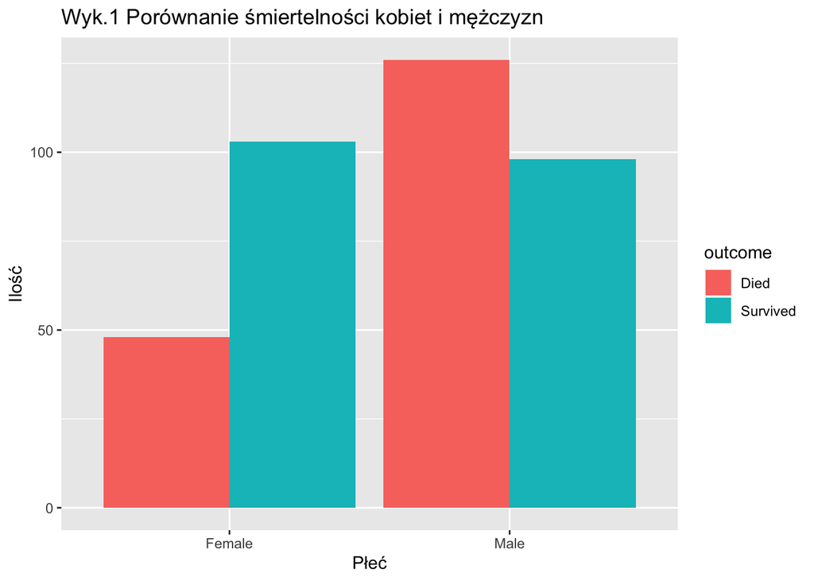

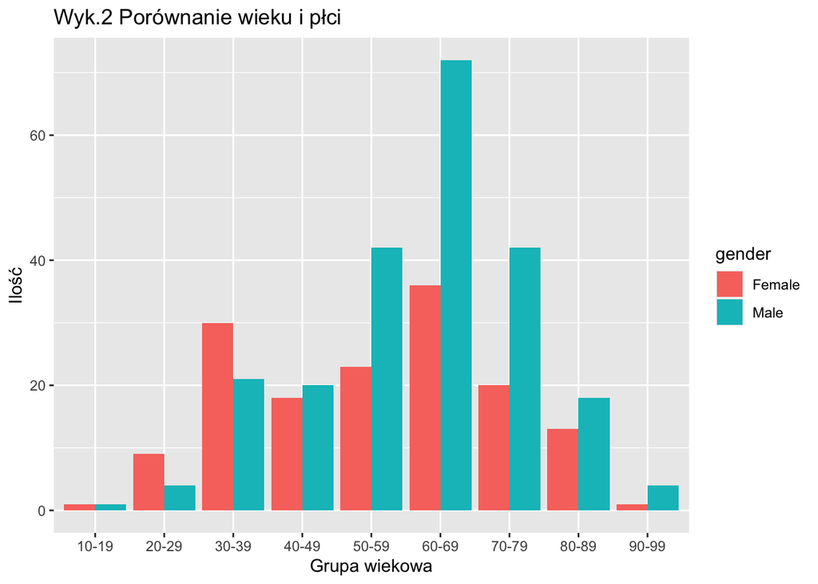

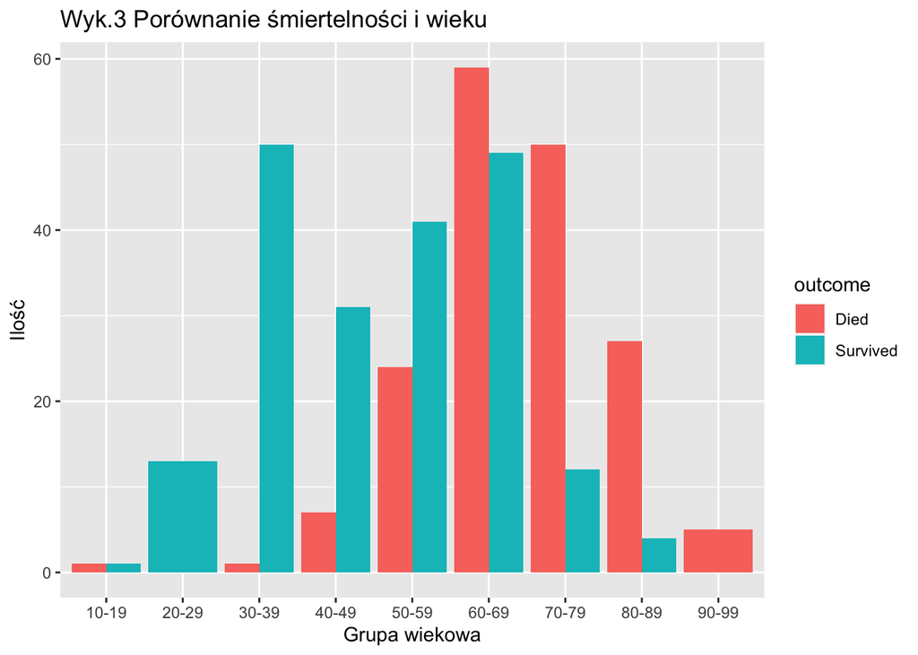